# Advanced Spatial Methods I

Peter Ganong and Maggie Shi

February 9, 2026

# Advanced Spatial Methods I

## Skills acquired by the end of this lecture

- Understand how to structure a data-intensive spatial project
- Use `sjoin` to compare/combine two GeoDataFrames
- Use `points_from_xy` to convert regular dataset with xy coordinates into spatial
- Apply principles of data visualization to spatial data

# Pre-processing

## Pre-processing: roadmap

- Before jumping into spatial content, “meta”-discussion on how this directory is organized
- Discuss structure of `spatial/` folder
- Walk through `preprocessing.py`
- *Note: some of this has been covered in mini-lesson on how to structure your final project. Here we will now go in further detail about why this structure is useful.*

## Structure of `spatial/` folder

- In the interest of time, we have pre-processed some of the raw data and shapefiles
- For your **projects** and **upcoming problem sets**, you should structure your data processing in a similar way (for all data, not just spatial)
- Why do this? **Replicability**, **transparency**, and **efficiency**

## Structure of `spatial/` folder

- `data/raw-data/`: where raw datasets are stored
- `data/derived-data/`: where derived datasets are stored
- `preprocessing.py`: code to process raw into derived data
- `README.md`: documents original data sources for raw data and explains how they are processed

## `spatial/raw-data/` folder

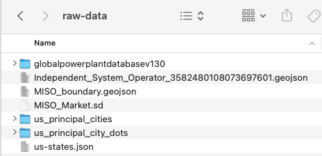

- These particular datasets are small enough (<100 MB) that they can be uploaded as part of Github repo
- But for larger datasets, you may have to share a Box/Dropbox/Google Drive folder and direct users to place data into `spatial/raw-data`

## `preprocessing.py`: set path

```python
current_wd = os.getcwd()
print(f"Working directory is now: {current_wd}")
```

```
Working directory is now: /Users/maggieshi/Documents/GitHub/winter2026/lectures/spatial
```

- Automatically detects and sets current working directory
- Allows user to fork + clone your repo and run it directly, rather than having to track down and update all the paths
- Use print statements liberally to check each step

## `preprocessing.py`

Example of code chunk to create `lower_48_states.geojson`

```python
output_path = "data/derived-data/lower_48_states.geojson"
if not os.path.exists(output_path):
    # code to process lower_48_states.geojson would be here
    print(f"GeoDataFrame successfully exported to: {output_path}")
else:
    print(f"Skipping: {output_path} already exists.")
```

```
Skipping: data/derived-data/lower_48_states.geojson already exists.
```

- **Efficiency**: to reduce runtime and avoid redundancy, check if output already exists in `derived-data/`
- Ensures that we run data processing code *only* if output does not already exist
- If you want to update file, must delete it and re-run

## `README.md`

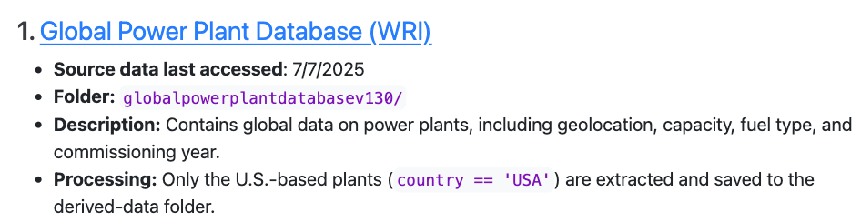

- For replication and transparency, always link to source data or cite your source
  - If source data not publicly available: explain how to get access
  - URLs change often – including “last accessed” helps a future user troubleshoot why they can’t find the data
- Include description of source data and processing to get derived data

## Pre-processing: summary

- When you are working with more complex tasks and data, structure your project directory to carefully
- **Efficiency**: do computationally-intensive tasks once in `preprocessing.py`, and build checks to reduce redundancy
- **Replicability** and **transparency**: clear and cohesive `README.md`

# Basic Spatial: Review

## Roadmap: basic spatial review

- Introduce context: U.S. electricity markets
- Spatial review: packages, loading data, basic visualization

## Intro to policy context + data: ISOs

- **Independent Systems Operators (ISOs)** are independent non-profit organizations that manage and coordinate the electric grid in the U.S.
  - Oversee and ensure reliable electricity transmission
  - Facilitate regional wholesale markets
- Each ISO covers a different geographic area, but not all their geographic boundaries are well-defined/follow state lines
- And not all regions in the U.S. covered by an ISO – only 2/3 of U.S. electricity load is served by an ISO

## Basic spatial review: loading packages and data

```python
import geopandas as gpd
import matplotlib.pyplot as plt
from matplotlib import patheffects as pe # used later to format text
import shapely
iso_gdf = gpd.read_file('data/derived-data/Independent_System_Operator.geojson')
```

- `geopandas` package can read in `.geojson`’s, in the same way that it reads in `.shp` and `.gpkg`
- `geojson`: JSON data type, but with spatial features like `geometry` and `coordinates`
- `iso_gdf` is a `GeoDataFrame`: a dataframe with spatial features + methods

## Basic spatial review: load data and inspect

```python
# count geometry by type
print("Geometry type:", iso_gdf.geom_type)

# count total number of features
print("\n N features:", len(iso_gdf))
```

```
Geometry type: 0    MultiPolygon
1    MultiPolygon
2    MultiPolygon
3    MultiPolygon
4    MultiPolygon
5    MultiPolygon
6    MultiPolygon
dtype: object

 N features: 7
```

## Basic spatial review: CRS

```python
# get CRS
print("\n Coordinate reference system:", iso_gdf.crs)
```

```
 Coordinate reference system: EPSG:4326
```

[figure not shown]

Source: epsg.io/4326

## Basic spatial review: CRS

- Recall that **Coordinate Reference Systems (CRS)** tells GIS packages how to project the data into 2D representation
- With `.geojson`, the CRS is embedded directly into the file
- Later as we combine different files together, have to remember to make sure the CRS’s are all aligned

## Basic spatial review: load data and inspect

```python
print(iso_gdf.head())
```

```
   OBJECTID     ID                                               NAME  \
0         1  56669  Midcontinent Independent Transmission System O...
1         2  59504                               Southwest Power Pool
2         3  14725                           Pjm Interconnection, Llc
3         4   5723        Electric Reliability Council Of Texas, Inc.
4         5   2775             California Independent System Operator

                      ADDRESS         CITY STATE    ZIP       TELEPHONE  \
0  720 WEST CITY CENTER DRIVE       CARMEL    IN  46032  (317) 249-5400
1           201 WORTHEN DRIVE  LITTLE ROCK    AR  72223  (501) 614-3200
2       2750 MONROE BOULEVARD      AUDUBON    PA  19403  (610) 666-8980
3     7620 METRO CENTER DRIVE       AUSTIN    TX  78744  (512) 225-7000
4         250 OUTCROPPING WAY       FOLSOM    CA  95630  (916) 351-4400

  COUNTRY NAICS_CODE  ...                                             SOURCE  \
```

[output cut: 35 more lines]

## Basic spatial review: basic visualization

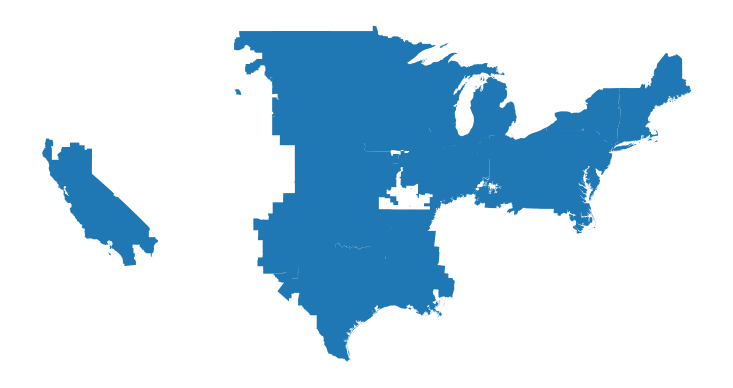

```python
iso_gdf.plot().set_axis_off()
```

**Discussion question**: what observations can you make after visualizing the geodata that you couldn’t before?

## Basic spatial review: summary

- Work with spatial data using `geopandas`
  - Load spatial file: `gpd.read_file()`
  - .`plot()` for basic visualization
- `.geojson` data type is a similar alternative to `.shp` and `.gpkg`
- Coordinate Reference System: tells `geopandas` how to project data

# Advanced Spatial Methods: roadmap

- Geometry objects like `GeoDataFrame` have a variety of methods that can…
  - Transform the object into something else: `centroid`, `union`
  - Make calculations: `length`, `area`
  - Combined separate objects together: `sjoin`
- The rest of the spatial lectures will be structured as case studies that explore use cases for these methods
- Next week, additional spatial package for dashboards: `pydeck`

## Use case 1: **characterize spatial relationships** – roadmap

- Zoom in on ISO covering Midwest: **MISO**
- **Motivating question**: which states does MISO cover (at least) part of?
- `sjoin`

## Zooming in on MISO

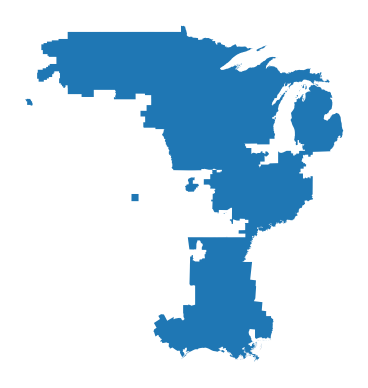

```python
# subset to MISO
miso_gdf = iso_gdf[iso_gdf["NAME"] ==
    "Midcontinent Independent Transmission System Operator, Inc.."]
miso_gdf.plot().set_axis_off()
```

## Which states does MISO cover part of?

End goal:

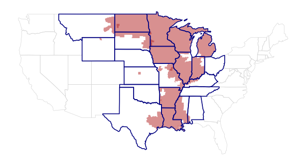

## Use case 1: characterize spatial relationships

- We can use spatial methods to compare two maps: MISO and state maps
- Want to know: **which states does MISO cover (at least) part of?**

## Use case 1: characterize spatial relationships

First, let’s load and inspect the state map we want to join with MISO: `lower_48_states.geojson`

```python
us_states_gdf = gpd.read_file('data/derived-data/lower_48_states.geojson')
us_states_gdf.crs = iso_gdf.crs
print(us_states_gdf.head())
```

```
   id        name  density                                           geometry
0  01     Alabama    94.65  POLYGON ((-87.3593 35.00118, -85.60668 34.9847...
1  04     Arizona    57.05  POLYGON ((-109.0425 37.00026, -109.04798 31.33...
2  05    Arkansas    56.43  POLYGON ((-94.47384 36.50186, -90.15254 36.496...
3  06  California   241.70  POLYGON ((-123.23326 42.00619, -122.37885 42.0...
4  08    Colorado    49.33  POLYGON ((-107.91973 41.00391, -105.72895 40.9...
```

- The states are denoted by `name`
- `us_states_gdf.crs = iso_gdf.crs` sets the two CRS’s to match

## Which states does MISO cover? – `sjoin`

- `sjoin` takes two GeoDataFrames and *creates a new one*
- Resulting gdf has variables from both dataframes
- Inputs to `sjoin`:
  - Left `GeoDataFrame`, right `GeoDataFrame`
  - `how`: `left`, `right`, `inner`
  - `predicate`: `intersects` (default), `contains`, `within`, `overlaps`…

## `sjoin`: `how`

`how`: determines *which* rows of *which* gdf survive

- `left`: all rows of **left** gdf survive, regardless of if they successfully join
- `inner`: *only* rows of **left** gdf that successfully join survive
- `right`: all rows of **right** gdf survive, regardless of if they successfully join

Note: if there is a 1:m join, the `sjoin` will duplicate rows

## `sjoin`: `predicate`

`predicate` captures the type of spatial join

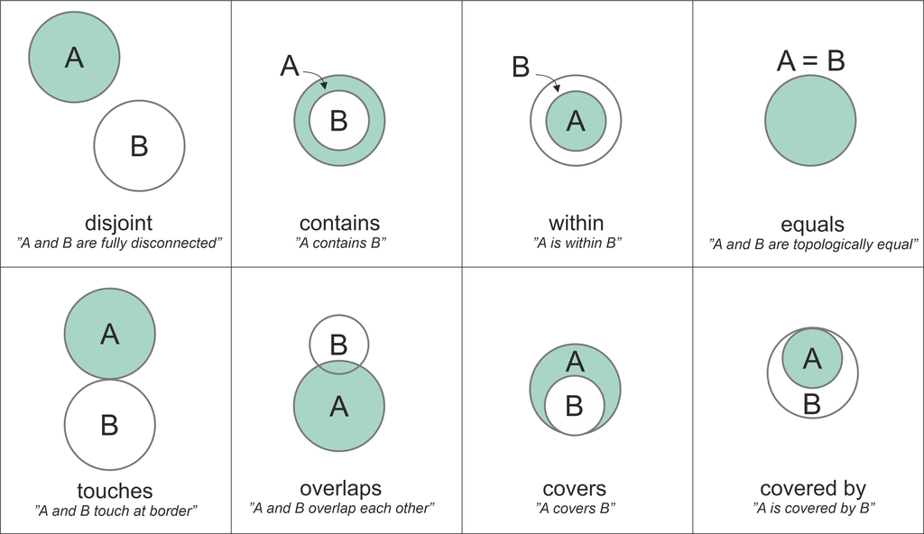

## Which states does MISO cover?

`intersects` is a more generalized version of `overlaps` that allows for different types of object types

```python
states_with_any_miso = gpd.sjoin(us_states_gdf,
    miso_gdf,
    how='inner',
    predicate='intersects')

print("Object type:", type(states_with_any_miso))
print("\nGeometry type:", states_with_any_miso.geom_type.value_counts())
```

```
Object type: <class 'geopandas.geodataframe.GeoDataFrame'>

Geometry type: Polygon         21
MultiPolygon     1
Name: count, dtype: int64
```

## Which states does MISO cover?

```python
print(states_with_any_miso.head())
```

```
    id      name  density                                           geometry  \
0   01   Alabama    94.65  POLYGON ((-87.3593 35.00118, -85.60668 34.9847...
2   05  Arkansas    56.43  POLYGON ((-94.47384 36.50186, -90.15254 36.496...
11  17  Illinois   231.50  POLYGON ((-90.63998 42.51006, -88.78878 42.493...
12  18   Indiana   181.70  POLYGON ((-85.99006 41.75972, -84.80704 41.759...
13  19      Iowa    54.81  POLYGON ((-91.36842 43.50139, -91.21506 43.501...

    index_right  OBJECTID     ID  \
0             0         1  56669
2             0         1  56669
11            0         1  56669
12            0         1  56669
13            0         1  56669

                                                 NAME  \
```

[output cut: 49 more lines]

```python
print("States covered by MISO (any amount):", states_with_any_miso["name"].tolist())
```

```
States covered by MISO (any amount): ['Alabama', 'Arkansas', 'Illinois', 'Indiana', 'Iowa', 'Kansas', 'Kentucky', 'Louisiana', 'Michigan', 'Minnesota', 'Mississippi', 'Missouri', 'Montana', 'Nebraska', 'North Dakota', 'Ohio', 'Oklahoma', 'South Dakota', 'Tennessee', 'Texas', 'Wisconsin', 'Wyoming']
```

## Plot for visual confirmation

For more complicated/layered spatial plots, use `matplotlib`

```python
# set up plot
fig, ax = plt.subplots(figsize=(8, 6))

# plot MISO in red
miso_gdf.plot(ax=ax, color='firebrick', alpha=0.5)

# plot all states in gray boundary
us_states_gdf.boundary.plot(ax=ax, color='lightgray', linewidth=0.5)

# plot inner join states in navy boundary
states_with_any_miso.boundary.plot(ax=ax, edgecolor='navy', linewidth=1.2)

ax.set_axis_off()
plt.show()
```

We will cover more on making production-quality maps next lecture

## Plot for visual confirmation

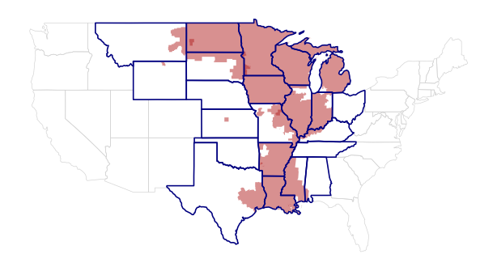

## Use case 1: **characterize spatial relationships** – summary

- Can use spatial methods to compare different maps and characterize spatial relationships in a systematic way
- Example: which states does MISO cover (at least) part of?
- Method: `sjoin`
- Use `matplotlib` for more complicated spatial maps

# Use Case 2: communicating spatial patterns

## Use case 2: communicating spatial patterns – roadmap

- **Motivating Question**: what is the spatial distribution of power plants by fuel type in the U.S.?
- Load new power plant dataset from **CSV**
- Convert to GeoDataframe using coordinates: `points_from_xy`
- Explore different ways of encoding categorical information to answer question

## Context: power plants

- We will next introduce a dataset on U.S. power plants: location, fuel type, and electricity generation
- Most power plants use a **primary fuel type** – natural gas, coal, nuclear, etc. – to generate electricity
- Power generation is measured in **gigawatt-hours** (GWh)
  - 1 GWh roughly powers 700 homes for a year

## A new dataset: US power plants

```python
us_powerplant_df = pd.read_csv('data/derived-data/us_gppd.csv')
print(us_powerplant_df.columns)
```

Note that this is *not* a spatial file type, but just a CSV

```
Index(['country', 'country_long', 'name', 'gppd_idnr', 'capacity_mw',
       'latitude', 'longitude', 'primary_fuel', 'other_fuel1', 'other_fuel2',
       'other_fuel3', 'commissioning_year', 'owner', 'source', 'url',
       'geolocation_source', 'wepp_id', 'year_of_capacity_data',
       'generation_gwh_2013', 'generation_gwh_2014', 'generation_gwh_2015',
       'generation_gwh_2016', 'generation_gwh_2017', 'generation_gwh_2018',
       'generation_gwh_2019', 'generation_data_source',
       'estimated_generation_gwh_2013', 'estimated_generation_gwh_2014',
       'estimated_generation_gwh_2015', 'estimated_generation_gwh_2016',
       'estimated_generation_gwh_2017', 'estimated_generation_note_2013',
       'estimated_generation_note_2014', 'estimated_generation_note_2015',
       'estimated_generation_note_2016', 'estimated_generation_note_2017'],
      dtype='object')
```

## Exploring `us_gppd.csv`

We are interested in fuel types. From the `README.txt`:

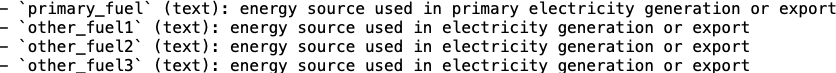

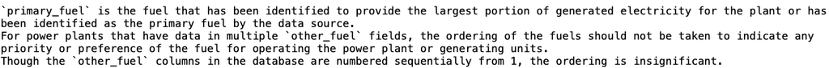

So we are interested in studying `primary_fuel`

```python
print(us_powerplant_df["primary_fuel"].unique())
```

```
['Solar' 'Gas' 'Oil' 'Hydro' 'Wind' 'Coal' 'Biomass' 'Waste' 'Storage'
 'Cogeneration' 'Geothermal' 'Petcoke' 'Nuclear' 'Other']
```

## Exploring `us_gppd.csv`

```python
summary = (
    us_powerplant_df
    .groupby("primary_fuel", as_index=False)["generation_gwh_2019"]
    .sum()
    .rename(columns={"generation_gwh_2019": "total_generation_gwh_2019"})
    .sort_values(by="total_generation_gwh_2019", ascending=False)
)

print(summary)
```

```
    primary_fuel  total_generation_gwh_2019
3            Gas               1.577508e+06
1           Coal               9.357724e+05
6        Nuclear               8.071456e+05
13          Wind               2.946884e+05
5          Hydro               2.804984e+05
10         Solar               7.142216e+04
12         Waste               4.378694e+04
0        Biomass               2.570438e+04
4     Geothermal               1.554570e+04
7            Oil               1.483142e+04
9        Petcoke               6.967579e+03
2   Cogeneration               3.888141e+03
8          Other               1.155774e+03
11       Storage              -6.636100e+01
```

## Loading `us_gppd.csv` as a `GeoDataFrame`

```python
us_powerplant_gdf = gpd.GeoDataFrame(
    geometry=gpd.points_from_xy(
        us_powerplant_df.longitude,
        us_powerplant_df.latitude,
        crs="EPSG:4326"),
    data=us_powerplant_df)

print("Geometry type:", us_powerplant_gdf.geom_type.value_counts())
```

```
Geometry type: Point    9581
Name: count, dtype: int64
```

## Visualizing `us_powerplant_gdf`

- Once we confirm that `us_powerplant_gdf` is on the same CRS as `us_states_gdf`
- We can plot one directly on the other

```python
assert(us_states_gdf.crs == us_powerplant_gdf.crs)
print("I've asserted that the CRS's match.")

fig, ax = plt.subplots(figsize=(8, 6))
us_states_gdf.boundary.plot(ax=ax, color='lightgray', linewidth=0.5)
us_powerplant_gdf.plot(ax=ax, markersize=1.5)
ax.set_axis_off()
plt.show()
```

## Visualizing `us_powerplant_gdf`

```
I've asserted that the CRS's match.
```

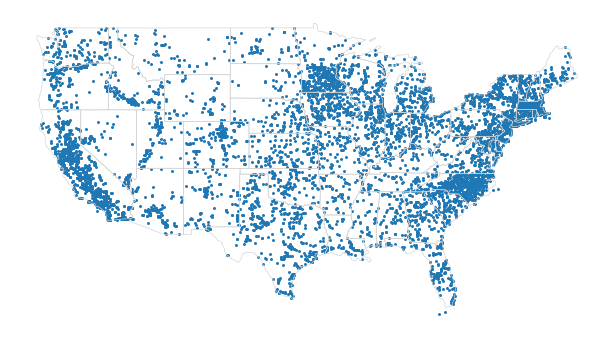

## Visualizing `us_powerplant_gdf`

- Recall our **motivating question**: what is the spatial distribution of power plants by fuel type in the U.S.?
- We have the ingredients to answer this question now:
  - `latitude` and `longitude` of power plants (converted into `GeoDataFrame`)
  - `primary_fuel`: categorical attribute
- As a first pass: let’s encode `primary_fuel` in different colors and plot

## Visualizing `us_powerplant_gdf`

```python
fig, ax = plt.subplots(figsize=(8, 6))
us_states_gdf.boundary.plot(ax=ax, color='lightgray', linewidth=0.5)

us_powerplant_gdf.plot(
    ax=ax,
    column='primary_fuel',
    categorical=True,
    legend=True,
    markersize=2,
    alpha=0.7
)
ax.set_axis_off()
ax.set_title("Power Plants by Primary Fuel Type", fontsize=14)
plt.tight_layout()
plt.show()
```

## Take 1: encoding fuels with color

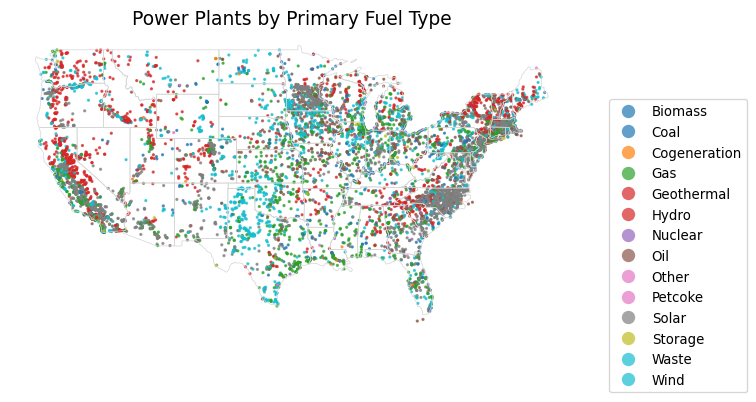

**Question**: what is the headline of this map? Sub-messages?

## Take 2: encoding top 4 fuels with color

The map on the previous slide is too cluttered. Let’s restrict just to the top 4 fuel types.

```python
# restrict to top 4 fuels by total gwh
top_fuels = summary["primary_fuel"].head(4)
filtered_powerplant_gdf = us_powerplant_gdf[us_powerplant_gdf["primary_fuel"].isin(top_fuels)]

fig, ax = plt.subplots(figsize=(8, 6))
us_states_gdf.boundary.plot(ax=ax, color='lightgray', linewidth=0.5)

# loop through each fuel type and plot
for fuel_type, group in filtered_powerplant_gdf.groupby("primary_fuel"):
    group.plot(ax=ax, markersize=3, label=fuel_type,alpha=0.7)

# define legend
ax.legend(title="Primary Fuel", fontsize=8, title_fontsize=8, loc="lower right", frameon=False)
ax.set_axis_off()
plt.tight_layout()
plt.show()
```

## Take 2: encoding top 4 fuels with color

[figure not shown]

**Discussion question**: what headlines/submessages come out now?

## Take 3: encoding with small multiples

Recall from visualization lectures: an alternative to color is *small multiples*:

```python
fig, axes = plt.subplots(2, 2, figsize=(6, 6), constrained_layout=True) # 2x2 subplots
axes = axes.flatten() # flatten for iteration

for ax, fuel_type in zip(axes, summary["primary_fuel"].head(4)):
    group = filtered_powerplant_gdf[filtered_powerplant_gdf["primary_fuel"] == fuel_type]
    group.plot(ax=ax, markersize=3, alpha=0.7, color='blue')
    us_states_gdf.boundary.plot(ax=ax, color='lightgray', linewidth=0.5)
    ax.set_title(fuel_type, fontsize=16)
    ax.set_axis_off()
plt.show()
```

- Define 2x2 subplots
- Iterate through each subplot and fuel type
- Plot points, subsetted to each fuel type

## Take 3: encoding with small multiples

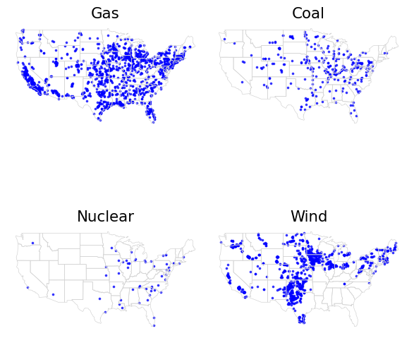

**Discussion questions**: what are the headlines and submessages now?

## Do-pair-share

**Motivating question**: create a small-multiples plot to depict the spatial distribution of power plants by fuel type (top 4) in *Illinois*.

Hints:

- Subset `us_states_gdf` to just Illinois
- Then use `.sjoin` from previous case study

```python
print(us_states_gdf.head())
```

```
   id        name  density                                           geometry
0  01     Alabama    94.65  POLYGON ((-87.3593 35.00118, -85.60668 34.9847...
1  04     Arizona    57.05  POLYGON ((-109.0425 37.00026, -109.04798 31.33...
2  05    Arkansas    56.43  POLYGON ((-94.47384 36.50186, -90.15254 36.496...
3  06  California   241.70  POLYGON ((-123.23326 42.00619, -122.37885 42.0...
4  08    Colorado    49.33  POLYGON ((-107.91973 41.00391, -105.72895 40.9...
```

## Do-pair-share: starter code

Code to plot small-multiples of top 4 fuel types nationally: `spatial1_dps.qmd`

```python
import geopandas as gpd
import pandas as pd
import matplotlib.pyplot as plt
from matplotlib import patheffects as pe # used later to format text
import shapely

# load geodata
us_states_gdf = gpd.read_file('data/derived-data/lower_48_states.geojson')
us_powerplant_df = pd.read_csv('data/derived-data/us_gppd.csv')
us_powerplant_gdf = gpd.GeoDataFrame(
    geometry=gpd.points_from_xy(
    us_powerplant_df.longitude,
    us_powerplant_df.latitude,
    crs="EPSG:4326"),
    data=us_powerplant_df)

# summarize top fuels by gwh in 2019
summary = (
    us_powerplant_df
    .groupby("primary_fuel", as_index=False)["generation_gwh_2019"]
    .sum()
    .rename(columns={"generation_gwh_2019": "total_generation_gwh_2019"})
    .sort_values(by="total_generation_gwh_2019", ascending=False)
)

# subset to power plants for top 4 fuels
filtered_powerplant_gdf = us_powerplant_gdf[us_powerplant_gdf["primary_fuel"].isin(summary["primary_fuel"].head(4))]

# initiate 2x2 subplots
fig, axes = plt.subplots(2, 2, figsize=(12, 10), constrained_layout=True) # 2x2 subplots
axes = axes.flatten() # flatten for iteration

# iterate through top 4 fuel power plants and plot
for ax, fuel_type in zip(axes, summary["primary_fuel"].head(4)):
    group = filtered_powerplant_gdf[filtered_powerplant_gdf["primary_fuel"] == fuel_type]
    group.plot(ax=ax, markersize=3, alpha=0.7, color='blue')

    us_states_gdf.boundary.plot(ax=ax, color='lightgray', linewidth=0.5)

    ax.set_title(fuel_type, fontsize=16)
    ax.set_axis_off()
plt.show()
```

## Use case 2: communicating spatial patterns – summary

- `points_from_xy` converts datasets with `latitude` and `longitude` into spatial data
- There are many ways to visualize spatial patterns – a lot the rules and concepts from standard data viz apply here too
  - Plotting as much information as possible is not necessarily optimal
  - Experiment with different ways of encoding information